# Changes to grid for R 3.0.0

From R 3.0.0, there is a new recommended way to develop new grob classes in *grid*. In a nutshell, two new “hook” functions, `makeContext()` and `makeContent()` have been added to *grid* to provide an alternative to the existing hook functions `preDrawDetails()`, `drawDetails()`, and `postDrawDetails()`. There is also a new function called `grid.force()`. This article discusses why these changes have been made, provides a simple demonstration of the use of the new functions, and discusses some of the implications for packages that build on *grid*.

Paul Murrell (Department of Statistics, The University of Auckland)  
2013-09-27

## 1 Introduction

The *grid* graphics package (Murrell 2011) provides a low-level graphics system as an alternative to the default *graphics* package. Several high-level graphics packages build on *grid*; for example, if we use [*lattice*](https://CRAN.R-project.org/package=lattice) (Sarkar 2008) or [*ggplot2*](https://CRAN.R-project.org/package=ggplot2) (Wickham 2009) to draw a plot, then we are also using *grid*.

This section shows a simple example of using *grid* that results in a problem, and this problem provides the motivation for the changes that were made to *grid* for R 3.0.0.

The following code uses the *grid* package to draw an axis.

```r
> library(grid)
```

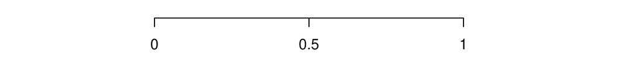

```r
> grid.xaxis(at=c(0, .5, 1), name="axis-1")
```

In addition to drawing the axis, *grid* keeps a list of graphical objects, or grobs, that contain descriptions of what has been drawn. The following code lists the grobs in the current scene: there is a parent grob called `"axis-1"` (this is actually a gTree, which is a grob that can have other grobs as children), and several child grobs including a "major" line, several "ticks" line segments, and several text "labels", all collected together to make an axis.

```r
> grid.ls(fullNames=TRUE)
```

```r
xaxis[axis-1]
  lines[major]
  segments[ticks]
  text[labels]
```

The *grid* package keeps a list of grobs because it can be useful to access, query, and modify the grobs in a scene. For example, the following code uses the `grid.edit()` function to change the lines on the axis to grey and the text to bold.

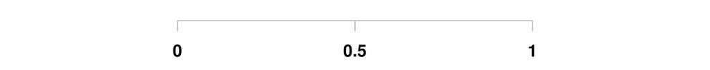

```r
> grid.edit("major|ticks", grep=TRUE, global=TRUE, gp=gpar(col="grey"))
> grid.edit("labels", gp=gpar(fontface="bold"))
```

### 1.1 A problem

The next piece of code also draws an axis, but this time we do not specify where the tick marks should go on the axis. There is also code to show the grobs that *grid* has kept as a record of this scene. The important difference to note is that this time the grob listing only shows the `"axis-2"` gTree; there are no grobs representing the lines, segments, and text on the axis.

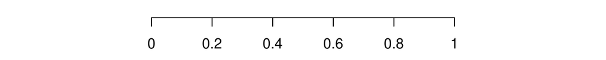

```r
> grid.xaxis(name="axis-2")
```

```r
> grid.ls(fullNames=TRUE)
```

```r
xaxis[axis-2]
```

This lack of child grobs is a problem because it means that it is not possible to access (or query or modify) the child grobs. The problem exists because, when the tick mark locations are not specified for an axis, the axis decides which tick marks to draw every time the axis is drawn - no child grobs are kept because they are recreated every time.

One of the reasons for the changes to *grid* in R 3.0.0 is to provide a solution for this problem. It is important to point out that many *grid* grobs do not suffer from this issue at all. This problem only occurs for a small set of *grid* grobs that decide what to draw at drawing time rather than at creation time. On the other hand, the problem becomes more likely in packages that build on *grid* and define new classes of *grid* grobs, so fixing the problem in *grid* has large flow-on effects to other packages.

One of the very visible changes to *grid* is the new function `grid.force()`. The following code shows that the `grid.force()` function can be used to create permanent versions of the child grobs for the axis, which then means that it is possible to modify those child grobs.

```r
> grid.force()
```

```r
> grid.ls(fullNames=TRUE)
```

```r
forcedgrob[axis-2]
  lines[major]
  segments[ticks]
  text[labels]
```

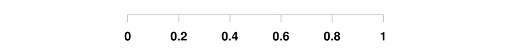

```r
> grid.edit("major|ticks", grep=TRUE, global=TRUE, gp=gpar(col="grey"))
> grid.edit("labels", gp=gpar(fontface="bold"))
```

The `grid.force()` function is just one of the changes to *grid* for R 3.0.0. This article describes the full set of changes, including more about `grid.force()`, and explores some of the other reasons for change and some of the other benefits that arise from these changes.

## 2 A simple *grid* demonstration

In order to demonstrate the changes in *grid*, we will consider several different ways to develop a function that draws a “text box” with *grid*. This function will draw a text label and surround the text with a box (with rounded corners). In effect, we are going to create a new class of grob; one that draws text surrounded by a box.

The simplest way to implement this sort of thing in *grid* is to write a function that makes several calls to draw standard *grid* grobs. For example, the following code defines a `textbox()` function that takes a single argument, a text label, and calls `textGrob()` to create a text grob, `roundrectGrob()` to create a box around the label, and then `grid.draw()` to draw the two grobs. The `stringWidth()` and `stringHeight()` functions are used to make sure that the box is the right size for the label.

```r
> library(grid)
```

```r
> textbox <- function(label) {
+     tg <- textGrob(label, name="text")
+     rr <- roundrectGrob(width=1.5*stringWidth(label),
+                         height=1.5*stringHeight(label),
+                         name="box")
+     grid.draw(tg)
+     grid.draw(rr)
+ }
```

```r
> grid.newpage()
> textbox("test")
```

The code and output below shows that *grid* has kept a record of the grobs that were drawn.

```r
> grid.ls(fullNames=TRUE)
```

```r
text[text]
roundrect[box]
```

One deficiency with the `textbox()` function is that there is no connection between the two grobs that it creates. For example, if we modify the text (code below), the roundrect stays the same size and becomes too small for the text (see the output below the code).

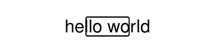

```r
> grid.edit("text", label="hello world")
```

An alternative implementation is to *group* the two grobs together by constructing a gTree to contain them both. For example, the following code redefines the `textbox()` function so that it generates a gTree containing a text grob and a roundrect grob and then draws the gTree.

```r
> textbox <- function(label) {
+     tg <- textGrob(label, name="text")
+     rr <- roundrectGrob(width=1.5*stringWidth(label),
+                         height=1.5*stringHeight(label),
+                         name="box")
+     gt <- gTree(children=gList(tg, rr), name="tb")
+     grid.draw(gt)
+ }
```

This version of the function produces the same output as the previous version, but the scene now consists of a single gTree that contains the text grob and the roundrect grob.

```r
> grid.newpage()
> textbox("test")
```

```r
> grid.ls(fullNames=TRUE)
```

```r
gTree[tb]
  text[text]
  roundrect[box]
```

Unfortunately, the contents of the gTree are fixed at creation time, so if we modify the text grob child of the gTree, the roundrect child is still not updated.

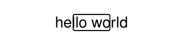

```r
> grid.edit("tb::text", label="hello world")
```

## 3 The old `drawDetails()` hook

The behaviour of the text box can be made more coherent if we delay the construction of the box until drawing time (i.e., recalculate the box every time that we draw the text box). That way, the box will always be the right size for the text. This can be achieved in *grid* by creating a new class of grob with the `grob()` function and then defining a `drawDetails()` method for this new grob class. For all grobs, the `drawDetails()` hook is called whenever the grob is drawn (with the default `drawDetails()` method doing nothing).

For example, the following code redefines the `textbox()` function so that it generates a grob with the class `"textbox"` and draws that.

```r
> textbox <- function(label,
+                     name=NULL, gp=NULL, vp=NULL) {
+     g <- grob(label=label,
+               name=name, gp=gp, vp=vp,
+               cl="textbox")
+     grid.draw(g)
+ }
```

Because we have created a new class of grob, *grid* does not know how to draw it. To tell *grid* how to draw a `"textbox"` grob, we can define a `drawDetails()` method for `"textbox"` grobs. Such a method is shown in the code below, which is almost identical to the previous version of `textbox()`; all that we have done is delay the generation of the text grob and roundrect grob until drawing time.

```r
> drawDetails.textbox <- function(x, ...) {
+     tg <- textGrob(x$label, name="text")
+     rr <- roundrectGrob(width=1.5*stringWidth(x$label),
+                         height=1.5*stringHeight(x$label),
+                         name="box")
+     gt <- gTree(children=gList(tg, rr), name=x$name)
+     grid.draw(gt)
+ }
```

The following code shows the new `textbox()` function in action and shows that it produces exactly the same output as the first version.

```r
> grid.newpage()
> textbox("test", name="tb")
```

One big difference is that only one `"textbox"` grob was generated, rather than separate text and roundrect grobs. The latter are only generated at drawing time and are not retained.

```r
> grid.ls(fullNames=TRUE)
```

```r
textbox[tb]
```

The advantage that we get is that, if we modify that one grob, both the text and the box are updated.

```r
> grid.edit("tb", label="hello world")
```

The disadvantage is that the individual text and box grobs are no longer visible as separate grobs, so it is not possible to access the individual text or roundrect grobs. In other words, we have a convenient high-level interface to the combined text and box, but we *only* have that high-level interface. This is the same problem that we had with the axis grob at the start of this article.

## 4 The new `makeContent()` hook

The new `makeContent()` function provides an alternative way to specify how to draw a new *grid* grob class (an alternative to writing a `drawDetails()` method). The main difference is that, whereas a `drawDetails()` method typically calls *grid* functions to *draw output*, a `makeContent()` method calls *grid* functions to *generate grobs*. The standard behaviour for grobs automatically takes care of drawing the content.

To continue our example, the following code redefines `textbox()` yet again. This is very similar to the previous version of `textbox()`. The one important difference in this new version is that the `gTree()` function is used to generate a new *gTree* class, rather than calling the `grob()` function to generate a new grob class. We do this because we are going to be writing a `makeContent()` method that creates more than one grob to draw; we can only use a `makeContent()` method for a grob class if the method only creates a single predefined grob to draw.[^1] The gTree does not get any children when it is created because the children will be built (and added) at drawing time by a `makeContent()` method.

```r
> textbox <- function(label,
+                     name=NULL, gp=NULL, vp=NULL) {
+     gt <- gTree(label=label,
+                 name=name, gp=gp, vp=vp,
+                 cl="textboxtree")
+     grid.draw(gt)
+ }
```

To tell *grid* how to draw this new gTree class, instead of a `drawDetails()` method, we define a `makeContent()` method. This is similar to the `drawDetails()` method above because it generates a text grob and a roundrect grob, but instead of drawing them, it simply adds these grobs as children of the gTree. The modified gTree must be returned as the result of this function so that *grid* can draw the generated content.

```r
> makeContent.textboxtree <- function(x) {
+     t <- textGrob(x$label,
+                   name="text")
+     rr <- roundrectGrob(width=1.5*grobWidth(t),
+                         height=1.5*grobHeight(t),
+                         name="box")
+     setChildren(x, gList(t, rr))
+ }
```

The following code shows that the new `textbox()` function produces exactly the same output as before.

```r
> grid.newpage()
> textbox("test", name="tbt")
```

As with the `drawDetails()` approach, the scene consists of only one grob, this time a `"textboxtree"` grob.

```r
> grid.ls(fullNames=TRUE)
```

```r
textboxtree[tbt]
```

Furthermore, if we modify that one grob, both the text and the box are updated.

```r
> grid.edit("tbt", label="hello world")
```

In summary, the `makeContent()` approach behaves exactly the same as the `drawDetails()` approach. The advantages of the `makeContent()` approach lie in the *extra* things that it allows us to do.

## 5 The `grid.force()` function

The new function `grid.force()` affects any grobs that have a `makeContent()` method. This function *replaces* the original grob with the modified grob that is returned by the `makeContent()` method.

```r
> grid.force()
```

However, the scene now consists of a gTree with a text grob and a roundrect grob as its children (rather than just a single `"textboxtree"` object).

```r
> grid.ls(fullNames=TRUE)
```

```r
forcedgrob[tbt]
  text[text]
  forcedgrob[box]
```

Now that we can see the individual components of the text box, we can modify them independently. For example, the following code just modifies the box component of the scene, but not the text component.

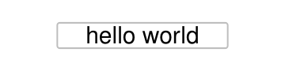

```r
> grid.edit("box", gp=gpar(col="grey"))
```

In other words, in addition to the convenient high-level interface to the text box, we can now “force” the high-level gTree to produce a low-level interface to the individual components of the text box.

### 5.1 Forced grobs

In the list of grobs above, the `"tbt"` grob is labelled as a `"forcedgrob"` after the call to `grid.force()`. This is an additional class that is attached to grobs that have been forced. The `"tbt"` grob is still a `"textboxtree"`, as shown below.

```r
> class(grid.get("tbt"))
```

```r
[1] "forcedgrob"  "textboxtree" "gTree"       "grob"        "gDesc"
```

The `"box"` grob in the example above has also been forced because *grid* `"roundrect"` grobs now have a `makeContent()` method. In this case, the forced grob is now a `"polygon"` grob (because the `makeContent()` method creates a `"polygon"` to draw based on the description in the `"roundrect"` grob).

```r
> class(grid.get("box"))
```

```r
[1] "forcedgrob" "polygon"    "grob"       "gDesc"
```

## 6 The `grid.revert()` function

One downside of calling `grid.force()` is that the convenient high-level interface to a grob is no longer available. For example, changing the label on the text box no longer has any effect.

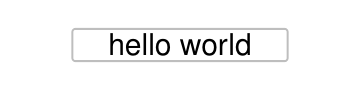

```r
> grid.edit("tbt", label="test")
```

The new `grid.revert()` function is provided to reverse the effect of `grid.force()` and replace the individual components of the forced grob with the original grob. The following code and shows this function in action. It also demonstrates that the reversion will lose any changes that were made to any of the individual components. We return to the scene that we had before the call to `grid.force()`.

```r
> grid.revert()
```

In other words, for grobs that generate content at drawing time, we can have *either* the high-level interface *or* the low-level interface, but not both at once.

## 7 A reminder

All of the discussion in this article applies to the situation where a new *grid* grob class is created that *needs to calculate what to draw at drawing time*. If the entire content of a grob or gTree can be generated at creation time, rather than having to wait until drawing time, then things are much easier, and it is possible to have both a high-level interface and low-level access at the same time.

It is only when the content must be generated at drawing time, as is the case for *grid* axis grobs, that the design decisions and functions described in this article become necessary.

## 8 Review

To review the changes described so far, where once we might have written a `drawDetails()` method for a new *grid* grob or gTree class, we can *instead* write a `makeContent()` method. If we do so, the new `grid.force()` function can be used to gain access to low-level grobs that otherwise would not be accessible. One example where this is useful is for *grid* axis grobs (with no tick location specified), in order to gain access to the individual lines and text that make up the axis.

## 9 Revisiting the simple *grid* demonstration

In order to demonstrate some of the other changes in *grid* for R 3.0.0, we will revisit the simple text box example from before. In the implementations of the `textbox()` function so far, we have focused our effort on what *content* to draw for the text box. In this section, we also consider the *context* for drawing; the *grid* viewports that a text box is drawn within.

In this next implementation, when a text box is drawn, we will set up a viewport to draw the text box within and then draw a text grob and roundrect grob within that viewport. This will simplify the creation of the text and roundrect grobs.

This change only requires modifications to the methods for the `"textboxtree"` class; the `textbox()` function remains the same as before.

```r
> textbox <- function(label,
+                     name=NULL, gp=NULL, vp=NULL) {
+     gt <- gTree(label=label,
+                 name=name, gp=gp, vp=vp,
+                 cl="textboxtree")
+     grid.draw(gt)
+ }
```

## 10 The old `preDrawDetails()` hook

We can specify how to set up the drawing context for a grob class by defining a `preDrawDetails()` method for the class. For all grobs, the `preDrawDetails()` hook is called *before* the `makeContent()` or `drawDetails()` hooks (with the default `preDrawDetails()` method doing nothing). The following code defines a method for `"textboxtree"` grobs that pushes a viewport the appropriate size for drawing the text box.

```r
> preDrawDetails.textboxtree <- function(x) {
+     tbvp <- viewport(width=1.5*stringWidth(x$label),
+                      height=1.5*stringHeight(x$label))
+     pushViewport(tbvp)
+ }
```

With this method defined, the `makeContent()` method for `"textboxtree"` grobs becomes much simpler because the roundrect grob just fills up the viewport that was created by the `preDrawDetails()` method (we have already calculated the appropriate size when we created the viewport in the `preDrawDetails()` method).

```r
> makeContent.textboxtree <- function(x) {
+     t <- textGrob(x$label, name="text")
+     rr <- roundrectGrob(name="box")
+     setChildren(x, gList(t, rr))
+ }
```

Whenever a `preDrawDetails()` method is defined, it must be accompanied by a `postDrawDetails()` method, which must revert any changes to the drawing context.

```r
> postDrawDetails.textboxtree <- function(x) {
+     popViewport()
+ }
```

The following code shows that the `textbox()` function produces exactly the same output as before.

```r
> grid.newpage()
> textbox("test", name="tbt")
```

The drawing context is regenerated every time the text box is drawn, so modifying the text label updates the viewport that both text and box are drawn in and the box expands with the text.

```r
> grid.edit("tbt", label="hello world")
```

## 11 The new `makeContext()` hook

In parallel with the change from `drawDetails()` to `makeContent()`, there is a new `makeContext()` generic function to replace the use of `preDrawDetails()` (and `postDrawDetails()`).

The main difference is that a `makeContext()` method must create new viewports and *add* them to the `vp` slot of the grob (rather than pushing the new viewports), *and* it must return the modified grob. The following code demonstrates what a `makeContext()` method looks like for a `"textboxtree"` grob.

```r
> makeContext.textboxtree <- function(x) {
+     tbvp <- viewport(width=1.5*stringWidth(x$label),
+                      height=1.5*stringHeight(x$label))
+     if (is.null(x$vp))
+         x$vp <- tbvp
+     else
+         x$vp <- vpStack(x$vp, tbvp)
+     x
+ }
```

This is similar to the `preDrawDetails()` method, but it has additional code to combine the new viewport with the current value of the `vp` slot for the grob. On the plus side, there is no need for a `postDrawDetails()` method. In fact, it is essential that we remove the `preDrawDetails()` and `postDrawDetails()` methods for this class; we only need the `makeContext()` method now.

```r
> rm("preDrawDetails.textboxtree")
> rm("postDrawDetails.textboxtree")
```

The following code shows that the `textbox()` function still works and that the box expands if we modify the text label.

```r
> grid.newpage()
> textbox("test", name="tbt")
```

```r
> grid.edit("tbt", label="hello world")
```

### 11.1 Mixing viewports with viewport paths

The example in the previous section contains another subtle change in *grid* for R 3.0.0. Within the `makeContext()` method there is the expression `vpStack(x$vp, tbvp)`. The `vpStack()` function combines two viewports into a viewport stack (one or more viewports that will be pushed in series, one after the other). The second argument to the call, `tbvp` is a viewport, but the first argument to the call is the `vp` slot of a grob, which could be a viewport *or* it could be a viewport path. The ability to combine viewport paths with viewports like this is new in R 3.0.0 and is necessary for `makeContext()` methods to work.

## 12 Another reminder

Modifying the drawing context at drawing time is not always necessary. When creating a new grob class, it is often simpler just to set up the drawing context at creation time by creating `childrenvp` for the children of a gTree. It is only when the generation of drawing context has to be delayed until drawing time that a `makeContext()` method becomes necessary.

## 13 Review

In addition to the new `makeContent()` hook for generating content at drawing time, and the new `grid.force()` function for exposing content that is only created at drawing time, there is a new `makeContext()` hook for generating context at drawing time.

The new `makeContext()` hook has been described, but it may not be clear what benefits accrue from it. That is the purpose of the next section.

## 14 Who benefits?

The problem with *grid* axes that was described at the start of this article has existed for many years. Having a solution for that problem scratches a years-long itch, but it was not the main reason for the changes in R 3.0.0. One of the motivations for changes to *grid* was provided by the difficulties that the authors of the [*gtable*](https://CRAN.R-project.org/package=gtable) package (Wickham 2012) had in implementing `"gtable"` grobs. The *gtable* package is important because it is used by the popular *ggplot2* package to arrange the different components of plots.

The *gtable* authors had to write not just `preDrawDetails()` and `postDrawDetails()` methods, but also `grid.draw()` methods to get the behaviour they desired for `"gtable"` grobs. This is undesirable because having a `grid.draw()` method makes `"gtable"` grobs behave differently from standard *grid* grobs. A symptom of this problem is the fact that not all grobs from a `"gtable"` are accessible for editing (similar to the axis problem at the start of this article). Having a special `grid.draw()` method also causes problems for packages that rely on the behaviour of standard *grid* grobs (as we shall see with the *gridSVG* package below).

The new `makeContext()` hook makes it possible to implement `"gtable"` grobs without resorting to a `grid.draw()` method. A new implementation is available as a fork of the *gtable* package on github.[^2]

Another motivator for change was the [*gridSVG*](https://CRAN.R-project.org/package=gridSVG) package (Murrell and S. Potter 2013). The main function of this package is to transform every grob in a *grid* scene into an SVG representation, but this package could not transform grobs that were not accessible (such as the ticks and labels for an axis grob). In fact, the package could not transform any grob that had a `drawDetails()` method because the grobs produced by a `drawDetails()` method were not recorded anywhere. The new `grid.force()` function (which depends on the new `makeContent()` hook) means that the *gridSVG* package can now access all of the grobs in a scene by “forcing” the scene before transforming it.

A number of grobs within *grid* itself, such as `"roundrect"` grobs and `"curve"` grobs, and several other packages, such as [*grImport*](https://CRAN.R-project.org/package=grImport) (Murrell 2009) and [*gridGraphviz*](https://CRAN.R-project.org/package=gridGraphviz) (Murrell 2013), have also switched to using `makeContext()` and `makeContent()` methods, with further flow-on effects for *gridSVG*.

## 15 When to use `makeContent()` or `makeContext()`

The new functions in *grid* for R 3.0.0 are only *necessary* when it is not possible to determine either the drawing context or the drawing content at creation time.

These functions *may* be used in other situations. The main text box example used in this article does not strictly require using `makeContent()` because an `editDetails()` method could be used instead. The `editDetails()` hook is called whenever a grob is modified by `grid.edit()`. In the main example, the box around the text label could be recreated if the text label is modified. So a developer could elect to use `makeContent()` in some cases just because it may be easier than writing an `editDetails()` method.

Another alternative is to use an `edits` slot on a grob. This works a bit like a panel function for *lattice* plots. The idea is that changes to the children of a gTree can be specified as part of the description of the gTree and then only applied at drawing time, using `applyEdits()`, once the children of the gTree have been created. This approach has actually been implemented for *grid* axis grobs, but has not proven popular and has not been implemented anywhere else. One way to look at the changes to *grid* for R 3.0.0 is as a replacement for that `edits` slot approach; one which will hopefully prove more popular because it has wider benefits.

One reason why a grob may wish to delay construction of its content until drawing time is because the grob is expected to undergo dramatic changes before drawing occurs. In this case, it is inefficient to update the contents of the grob every time it is modified; it is better to wait until drawing time and perform the construction only once. The `"gtable"` class from the *gtable* package is an example of this sort of grob.

These are only examples of situations that might motivate the use of `makeContext()` and `makeContent()`. In some cases, the decision will be forced, but in other cases the choice may be deliberate, so there is no fixed rule for when we might need to use these functions.

It is also important to remember that simpler options may exist because *grid* already delays many calculations until drawing time via the use of `gp` and `vp` slots on grobs and the use of units for locations and dimensions. While it would be wrong to characterise these functions as a “last resort”, developers of new grob classes should think at least twice before deciding that they are the best solution.

## 16 Other hook functions

In addition to the superceded `drawDetails()`, `preDrawDetails()`, and `postDrawDetails()` hook functions, and the `editDetails()` hook that was mentioned in the previous section, there are several other hook functions in *grid*.

The `validDetails()` function is called whenever a grob is created or edited. This can be used to check that the slots of a grob contain valid values. It is unaffected by the changes to *grid* described in this article.

The `widthDetails()` function is called when a `"grobwidth"` unit is evaluated, to determine the width of a grob. There is a similar function `heightDetails()`, plus `xDetails()` and `yDetails()` for determining locations on the boundary of a grob. Although these functions are not directly affected by the changes to *grid*, there are likely to be opportunities for code sharing between methods for these functions and `makeContent()` methods because grobs that have to calculate what to draw at drawing time are likely to have to also calculate what to draw in order to determine widths and heights or locations on a grob boundary.

## 17 Who else could benefit?

A number of packages besides *ggplot2* and *gridSVG* build on top of *grid* and therefore could take advantage of the new changes to *grid*. One example is version 0.9.1 of the [*gridExtra*](https://CRAN.R-project.org/package=gridExtra) package (Auguie 2012).

```r
> library(gridExtra)
```

The following code uses the `grid.table()` function from *gridExtra* to draw a tabular arrangement of values from a data frame.

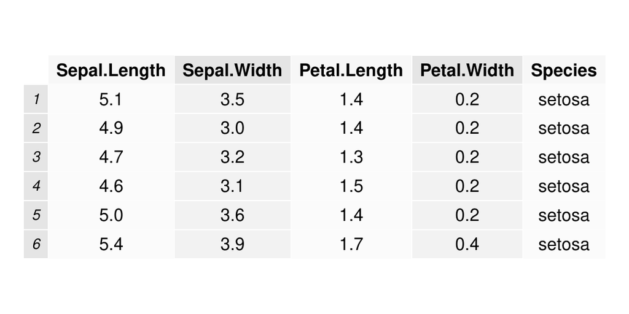

```r
> grid.newpage()
> grid.table(head(iris),
+            v.even.alpha=0.3, v.odd.alpha=1)
```

The `grid.table()` function creates a `"table"` grob with a `drawDetails()` method that determines how to arrange the contents of the table only at drawing time. Because of this, none of the grobs that represent the actual table content are accessible. The call to `grid.ls()` below only reveals the overall `"table"` grob, but no other grobs, so there is no way to access or modify the contents of the table.

```r
> grid.ls()
```

```r
GRID.table.2
```

A further consequence is that the *gridSVG* package, which attempts to transform all grobs in the current scene to SVG, has nothing to transform; the code below produces a blank SVG image.

```r
> library(gridSVG)
```

```r
> gridToSVG("blank.svg")
```

[figure not shown]

If there was a `makeContent()` method for `"table"` grobs, instead of a `drawDetails()` method, the function `grid.table()` would produce the same drawing, but it would become possible to `grid.force()` a `"table"` to make the grobs representing the content of the table accessible. The following code shows an example of how this could work, with `grid.edit()` used to modify the background colour for one of the cells in the table.

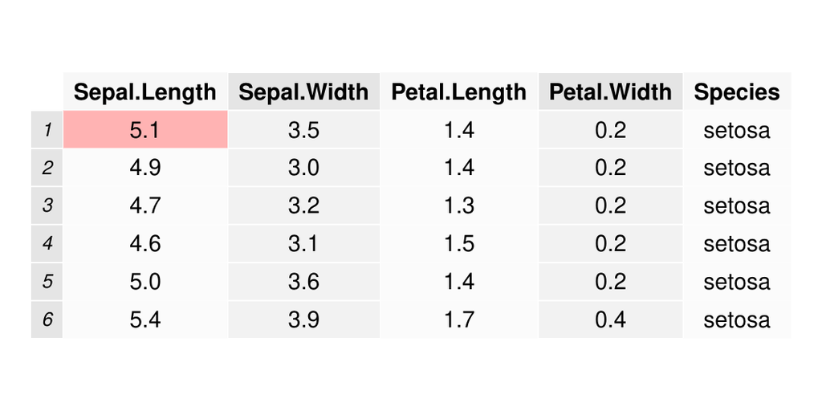

```r
> grid.newpage()
> grid.table(head(iris),
+            v.even.alpha=0.3, v.odd.alpha=1)
> grid.force()
> grid.edit("core-fill-1", gp=gpar(fill="red"))
```

Furthermore, export to SVG via the *gridSVG* package would now work, as shown below.

```r
> gridToSVG("notblank.svg")
```

[figure not shown]

## 18 Summary

The functions `makeContext()` and `makeContent()` provide a new approach to developing a new *grid* grob class (replacing the old approach based on `drawDetails()` and `preDrawDetails()`).

The advantage of the new approach is that, for grobs that generate content at drawing time, it is possible to access and edit the low-level content that is generated at drawing time by calling the `grid.force()` function.

Together, these new features allow for greater flexibility in the development of new *grid* grob classes and greater powers to access and modify the low-level details of a *grid* scene.

## 19 Availability

The new *grid* functions `makeContext()`, `makeContent()`, `grid.force()`, and `grid.revert()` are only available from R version 3.0.0.

A number of higher-level graphics packages can potentially make use of these new facilities in *grid*, but it may take time for the respective package maintainers to make the necessary changes (if they elect to do so at all). For example, versions 0.9-0 of the *grImport* package and version 1.3-0 of the *gridSVG* package on R-Forge (Theußl and Zeileis 2009) have incorporated changes. An example where future development may occur is `"gtable"` grobs from the *gtable* package, if changes from the fork on github are merged back into the original package.

## 20 Further reading

A more technical document describing the development and testing of these changes is available from the R developer web site (http://www.stat.auckland.ac.nz/~paul/R/customGridRedesign.pdf).

An earlier version of this article appeared as Technical Report 2012-9 on the Statistics Technical Blog of the Department of Statistics at the University of Auckland (Murrell 2012).

## 21 Acknowledgements

Thanks to the reviewers of early versions of this article, who provided many useful suggestions that improved and expanded the article. Thanks also to the developers of *gtable* who provided the nudge to finally tackle the *grid* axis problem properly.

### 21.1 CRAN packages used

lattice, ggplot2, gtable, gridSVG, grImport, gridGraphviz, gridExtra

### 21.2 CRAN Task Views implied by cited packages

ChemPhys, NetworkAnalysis, Phylogenetics, Spatial, TeachingStatistics

B. Auguie. *gridExtra: Functions in grid graphics, .* R package version 0.9.1, 2012. URL http://CRAN.R-project.org/package=gridExtra.

P. Murrell and S. Potter. *gridSVG: Export grid graphics as SVG, .* R package version 1.3-0, 2013.

P. Murrell. *gridGraphviz: Drawing graphs with grid, .* R package version 0.2, 2013. URL http://CRAN.R-project.org/package=gridGraphviz.

P. Murrell. *Importing vector graphics: The grImport package for R.* Journal of Statistical Software 30 (4):, 2009. URL http://www.jstatsoft.org/v30/i04/.

P. Murrell. *R graphics.* 2nd ed CRC Press, 2011.

P. Murrell. *Writing grid extensions.* Technical Report -9 Department of Statistics The University ofAuckland, 2012. URL http://stattech.wordpress.fos.auckland.ac.nz/2012-9-writing-grid-extensions/2012.

D. Sarkar. *Lattice: Multivariate Data Visualization with R.* Springer New York, 2008. URL http://lmdvr.r-forge.r-project.org.

S. Theußl and A. Zeileis. Collaborative Software Development Using R-Forge. *The R Journal*, 1(1): 9–14, 2009. URL http://journal.r-project.org/2009-1/RJournal_2009-1_Theussl+Zeileis.pdf.

H. Wickham. *ggplot2: Elegant graphics for data analysis.* Springer New York, 2009. URL http://had.co.nz/ggplot2/book.

H. Wickham. *gtable: Arrange grobs in tables., .* R package version 0.1.2, 2012. URL http://CRAN.R-project.org/package=gtable.

[^1]: We also create a different class than before, called `"textboxtree"` so that we do not have both `drawDetails()` and `makeContent()` methods defined for the same class.
[^2]: https://github.com/pmur002/gtable